# Assignment 2: Distributions and Proportions Part 2

Julia Meinhardt

9/15/2020

```r
library(ggplot2)
library(tidyverse)
library(ggthemes)
```

### Reading csv, filtering by region, and attaching.

```r
Bay_tract_data <- read_csv("jeffersonbay2018.csv") %>%
  filter(region == "Bay")
attach(Bay_tract_data)
```

### Assignment Deliverables

For each continuous variable in your dataset calculate:

1.sample mean 2.sample standard deviation 3.95-percent confidence interval for the population mean 4.interquartile range.

Create a histogram to illustrate the distribution of each variable and describe the distribution in a sentence or two.

For each categorical variable in your dataset calculate: 1.95-percent confidence interval for the proportion of the population in each category

**List of Variables**

1.**female_popE** (continuous) 2.**male_popE** (continuous)

3.**poverty_100** : total below 100% poverty level (continuous) 4.**poverty_149** : total from 100 to 149% of poverty Level (continuous) 5.**poverty_150** : total at or above 150% of poverty level (continuous)

6.**public_assist** : households receiving public assistance (including ss) (continuous) 7.**cash_assist** : households receiving public assistance, cash and food stamps (continuous) 8.**no_assist** (continuous)

9.**majority_hs_grads** (categorical)

10. **county** (categorical)
11. **region** (categorical)

## Calculations and Distributions for Bay Region

### Female Pop Summary Stats and Distribution

```r
summary(female_popE)
```

```
##    Min. 1st Qu.  Median    Mean 3rd Qu.    Max.
##       0    1783    2348    2432    2984    7456
```

```r
sd(female_popE)
```

```
## [1] 964.9275
```

```r
pop_mean9 <- t.test(female_popE)
pop_mean9
```

```
##
##  One Sample t-test
##
## data:  female_popE
## t = 100.44, df = 1587, p-value < 2.2e-16
## alternative hypothesis: true mean is not equal to 0
## 95 percent confidence interval:
##  2384.693 2479.683
## sample estimates:
## mean of x
##  2432.188
```

```r
hist9 <- ggplot(Bay_tract_data, aes(x = female_popE)) +
  geom_histogram()
```

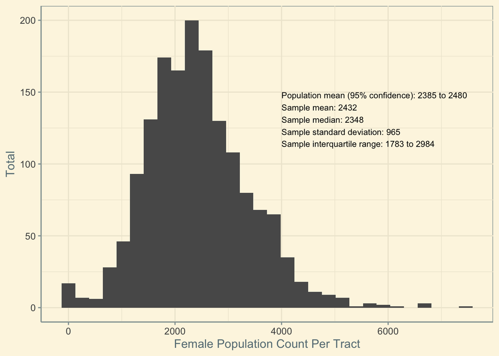

```r
hist9+
  theme_solarized() +
  scale_x_continuous(name = "Female Population Count Per Tract") +
  scale_y_continuous(name = "Total") +
  annotate("text", x = 4000, y = 150, size = 3,
           label = paste("Population mean (95% confidence):",
                         prettyNum(pop_mean9$conf.int[1], digits = 0),
                         "to",
                         prettyNum(pop_mean9$conf.int[2], digits = 0),

                         "\nSample mean:",
                         prettyNum(mean(female_popE), digits = 0),
                         "\nSample median:",
                         prettyNum(median(female_popE), digits = 0),
                         "\nSample standard deviation:",
                         prettyNum(sd(female_popE), digits = 0),
                         "\nSample interquartile range:",
                         prettyNum(quantile(female_popE)["25%"], digits = 0),
                         "to",
                         prettyNum(quantile(female_popE)["75%"], digits = 0)),
           hjust = 0, vjust = 1)
```

All of the histograms in this dataset are smoother with fewer outliers than the Jefferson data set. This makes sense given the much larger number of observations. From this analysis, I have begun to wonder about data gathering and statistics for rural areas and how sample size might problematically effect data representation.

### Male Pop Summary Stats and Distribution

```r
summary(male_popE)
```

```
##    Min. 1st Qu.  Median    Mean 3rd Qu.    Max.
##       0    1745    2304    2401    2934    7970
```

```r
sd(male_popE)
```

```
## [1] 972.2328
```

```r
pop_mean10 <- t.test(male_popE)
pop_mean10
```

```
##
##  One Sample t-test
##
## data:  male_popE
## t = 98.43, df = 1587, p-value < 2.2e-16
## alternative hypothesis: true mean is not equal to 0
## 95 percent confidence interval:
##  2353.584 2449.293
## sample estimates:
## mean of x
##  2401.438
```

```r
hist10 <- ggplot(Bay_tract_data, aes(x = male_popE)) +
  geom_histogram()
```

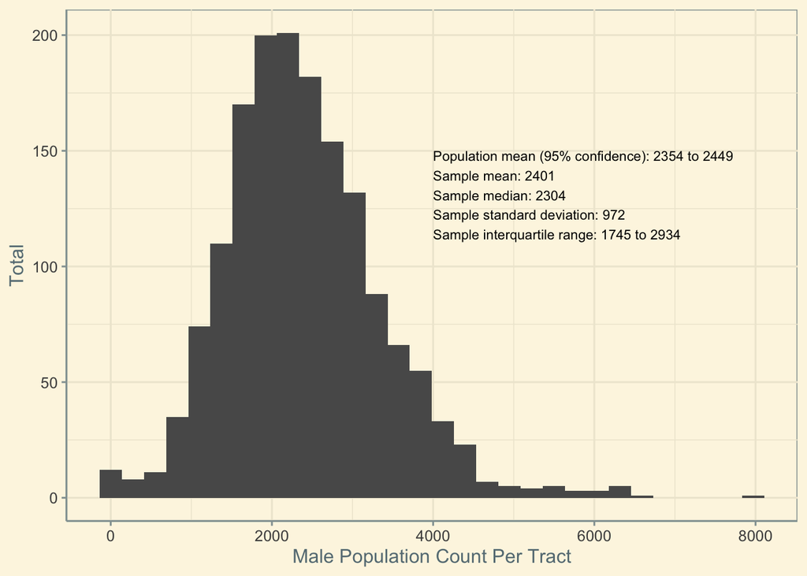

```r
hist10+
  theme_solarized() +
  scale_x_continuous(name = "Male Population Count Per Tract") +
  scale_y_continuous(name = "Total") +
  annotate("text", x = 4000, y = 150, size = 3,
           label = paste("Population mean (95% confidence):",
                         prettyNum(pop_mean10$conf.int[1], digits = 0),
                         "to",
                         prettyNum(pop_mean10$conf.int[2], digits = 0),

                         "\nSample mean:",
                         prettyNum(mean(male_popE), digits = 0),
                         "\nSample median:",
                         prettyNum(median(male_popE), digits = 0),
                         "\nSample standard deviation:",
                         prettyNum(sd(male_popE), digits = 0),
                         "\nSample interquartile range:",
                         prettyNum(quantile(male_popE)["25%"], digits = 0),
                         "to",
                         prettyNum(quantile(male_popE)["75%"], digits = 0)),
           hjust = 0, vjust = 1)
```

### Population Below 100% Poverty Level Summary Stats and Distribution

```r
summary(poverty_100E)
```

```
##    Min. 1st Qu.  Median    Mean 3rd Qu.    Max.
##     0.0   177.0   315.0   437.8   585.2  3303.0
```

```r
sd(poverty_100E)
```

```
## [1] 380.111
```

```r
pop_mean11 <- t.test(poverty_100E)
pop_mean11
```

```
##
##  One Sample t-test
##
## data:  poverty_100E
## t = 45.902, df = 1587, p-value < 2.2e-16
## alternative hypothesis: true mean is not equal to 0
## 95 percent confidence interval:
##  419.1323 456.5515
## sample estimates:
## mean of x
##  437.8419
```

```r
hist11<- ggplot(Bay_tract_data, aes(x = poverty_100E)) +
  geom_histogram()
```

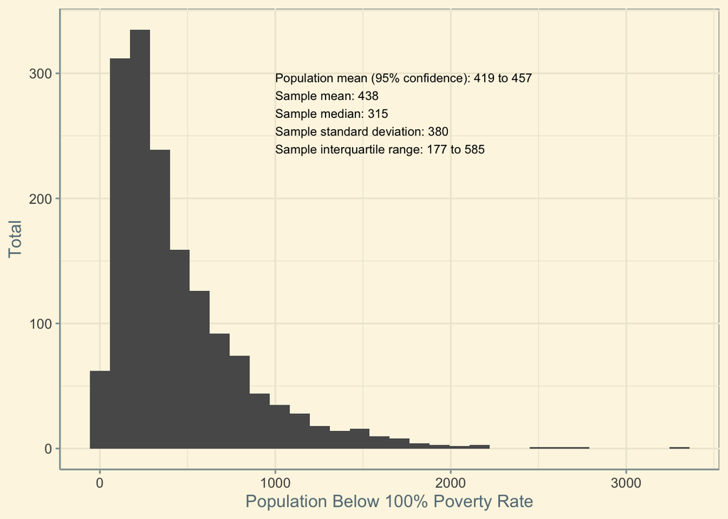

```r
hist11+
  theme_solarized() +
  scale_x_continuous(name = "Population Below 100% Poverty Rate") +
  scale_y_continuous(name = "Total") +
  annotate("text", x = 1000, y = 300, size = 3,
           label = paste("Population mean (95% confidence):",
                         prettyNum(pop_mean11$conf.int[1], digits = 0),
                         "to",
                         prettyNum(pop_mean11$conf.int[2], digits = 0),

                         "\nSample mean:",
                         prettyNum(mean(poverty_100E), digits = 0),
                         "\nSample median:",
                         prettyNum(median(poverty_100E), digits = 0),
                         "\nSample standard deviation:",
                         prettyNum(sd(poverty_100E), digits = 0),
                         "\nSample interquartile range:",
                         prettyNum(quantile(poverty_100E)["25%"], digits = 0),
                         "to",
                         prettyNum(quantile(poverty_100E)["75%"], digits = 0)),
           hjust = 0, vjust = 1)
```

The mean for the population below 100% poverty is greater than the mean for the population between 100-149%. I would need to learn more about the values for these ranges to provide a good explanation, but it could be an indication that there are greater disparities in wealth that are visible in the Bay that aren’t visible in the Jefferson data.

### Poulation Between 100 and 149 % Poverty Level Summary Stats and Distribution

```r
summary(poverty_149E)
```

```
##    Min. 1st Qu.  Median    Mean 3rd Qu.    Max.
##     0.0    96.0   203.0   281.9   383.0  1998.0
```

```r
sd(poverty_149E)
```

```
## [1] 267.7009
```

```r
pop_mean12 <- t.test(poverty_149E)
pop_mean12
```

```
##
##  One Sample t-test
##
## data:  poverty_149E
## t = 41.965, df = 1587, p-value < 2.2e-16
## alternative hypothesis: true mean is not equal to 0
## 95 percent confidence interval:
##  268.7314 295.0847
## sample estimates:
## mean of x
##  281.9081
```

```r
hist12 <- ggplot(Bay_tract_data, aes(x = poverty_149E)) +
  geom_histogram()
```

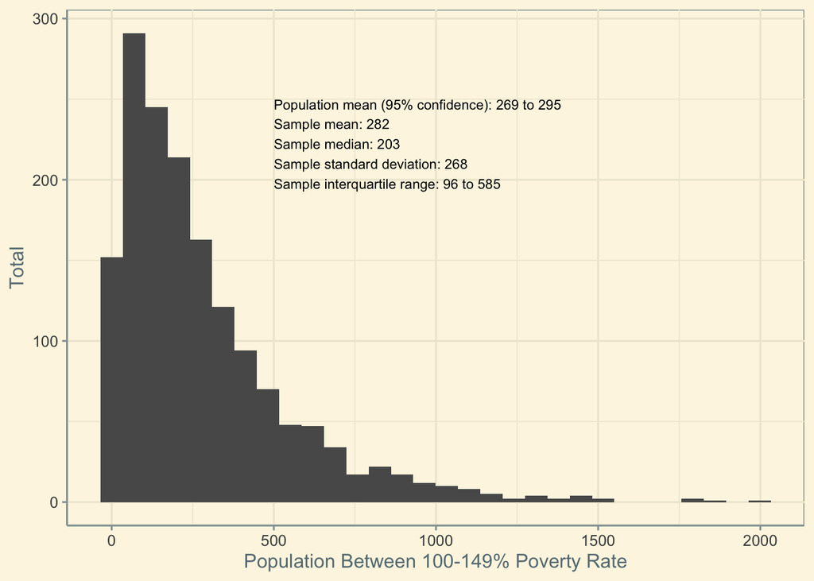

```r
hist12+
  theme_solarized() +
  scale_x_continuous(name = "Population Between 100-149% Poverty Rate") +
  scale_y_continuous(name = "Total") +
  annotate("text", x = 500, y = 250, size = 3,
           label = paste("Population mean (95% confidence):",
                         prettyNum(pop_mean12$conf.int[1], digits = 0),
                         "to",
                         prettyNum(pop_mean12$conf.int[2], digits = 0),

                         "\nSample mean:",
                         prettyNum(mean(poverty_149E), digits = 0),
                         "\nSample median:",
                         prettyNum(median(poverty_149E), digits = 0),
                         "\nSample standard deviation:",
                         prettyNum(sd(poverty_149E), digits = 0),
                         "\nSample interquartile range:",
                         prettyNum(quantile(poverty_149E)["25%"], digits = 0),
                         "to",
                         prettyNum(quantile(poverty_100E)["75%"], digits = 0)),
           hjust = 0, vjust = 1)
```

### Population over 150% Poverty Rate Summary Stats and Distribution

```r
summary(poverty_150E)
```

```
##    Min. 1st Qu.  Median    Mean 3rd Qu.    Max.
##       0    2919    3892    4043    5004   12960
```

```r
sd(poverty_150E)
```

```
## [1] 1723.129
```

```r
pop_mean13 <- t.test(poverty_150E)
pop_mean13
```

```
##
##  One Sample t-test
##
## data:  poverty_150E
## t = 93.498, df = 1587, p-value < 2.2e-16
## alternative hypothesis: true mean is not equal to 0
## 95 percent confidence interval:
##  3958.086 4127.715
## sample estimates:
## mean of x
##  4042.901
```

```r
hist13 <- ggplot(Bay_tract_data, aes(x = poverty_150E)) +
  geom_histogram()
```

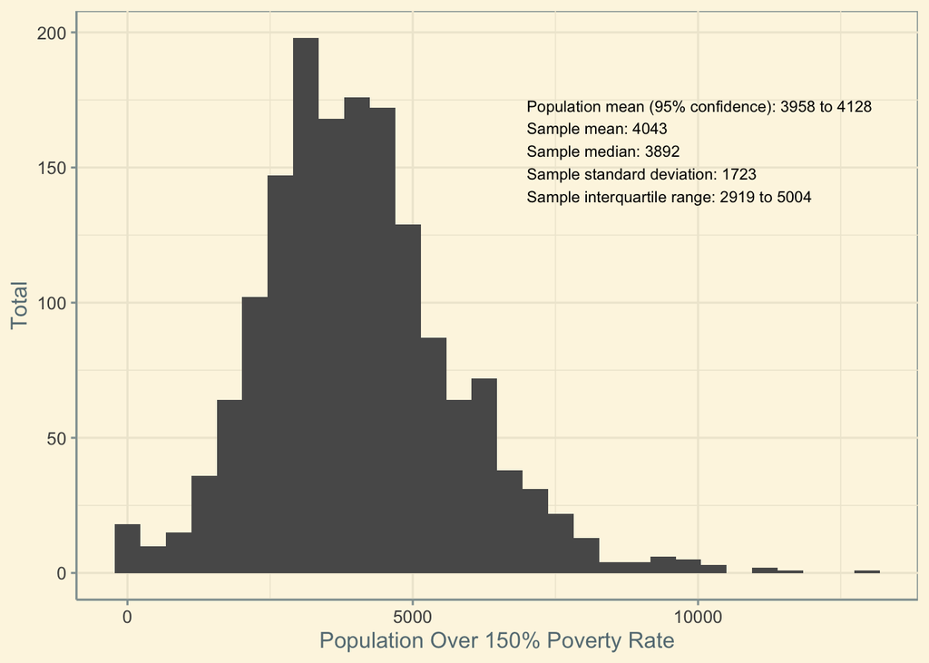

```r
hist13+
  theme_solarized() +
  scale_x_continuous(name = "Population Over 150% Poverty Rate") +
  scale_y_continuous(name = "Total") +
  annotate("text", x = 7000, y = 175, size = 3,
           label = paste("Population mean (95% confidence):",
                         prettyNum(pop_mean13$conf.int[1], digits = 0),
                         "to",
                         prettyNum(pop_mean13$conf.int[2], digits = 0),

                         "\nSample mean:",
                         prettyNum(mean(poverty_150E), digits = 0),
                         "\nSample median:",
                         prettyNum(median(poverty_150E), digits = 0),
                         "\nSample standard deviation:",
                         prettyNum(sd(poverty_150E), digits = 0),
                         "\nSample interquartile range:",
                         prettyNum(quantile(poverty_150E)["25%"], digits = 0),
                         "to",
                         prettyNum(quantile(poverty_150E)["75%"], digits = 0)),
           hjust = 0, vjust = 1)
```

### Population Receiving Public Assistance Summary Stats and Distribution

```r
summary(pub_assistE)
```

```
##    Min. 1st Qu.  Median    Mean 3rd Qu.    Max.
##       0    1240    1644    1710    2122    7900
```

```r
sd(pub_assistE)
```

```
## [1] 689.7078
```

```r
pop_mean14 <- t.test(pub_assistE)
pop_mean14
```

```
##
##  One Sample t-test
##
## data:  pub_assistE
## t = 98.783, df = 1587, p-value < 2.2e-16
## alternative hypothesis: true mean is not equal to 0
## 95 percent confidence interval:
##  1675.756 1743.652
## sample estimates:
## mean of x
##  1709.704
```

```r
hist14 <- ggplot(Bay_tract_data, aes(x = pub_assistE)) +
  geom_histogram()
```

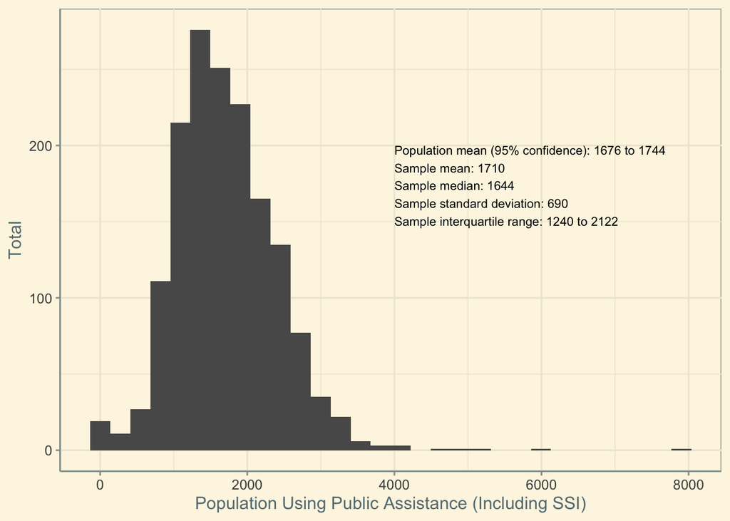

```r
hist14+
  theme_solarized() +
  scale_x_continuous(name = "Population Using Public Assistance (Including SSI)") +
  scale_y_continuous(name = "Total") +
  annotate("text", x = 4000, y = 200, size = 3,
           label = paste("Population mean (95% confidence):",
                         prettyNum(pop_mean14$conf.int[1], digits = 0),
                         "to",
                         prettyNum(pop_mean14$conf.int[2], digits = 0),

                         "\nSample mean:",
                         prettyNum(mean(pub_assistE), digits = 0),
                         "\nSample median:",
                         prettyNum(median(pub_assistE), digits = 0),
                         "\nSample standard deviation:",
                         prettyNum(sd(pub_assistE), digits = 0),
                         "\nSample interquartile range:",
                         prettyNum(quantile(pub_assistE)["25%"], digits = 0),
                         "to",
                         prettyNum(quantile(pub_assistE)["75%"], digits = 0)),
           hjust = 0, vjust = 1)
```

### Population Receiving Public Assistance (cash or food stamps) Summary Stats and Distribution

```r
summary(cash_assistE)
```

```
##    Min. 1st Qu.  Median    Mean 3rd Qu.    Max.
##     0.0    34.0    77.0   112.7   155.2   902.0
```

```r
sd(cash_assistE)
```

```
## [1] 109.653
```

```r
pop_mean15 <- t.test(cash_assistE)
pop_mean15
```

```
##
##  One Sample t-test
##
## data:  cash_assistE
## t = 40.951, df = 1587, p-value < 2.2e-16
## alternative hypothesis: true mean is not equal to 0
## 95 percent confidence interval:
##  107.2853 118.0799
## sample estimates:
## mean of x
##  112.6826
```

```r
hist15 <- ggplot(Bay_tract_data, aes(x = cash_assistE)) +
  geom_histogram()
```

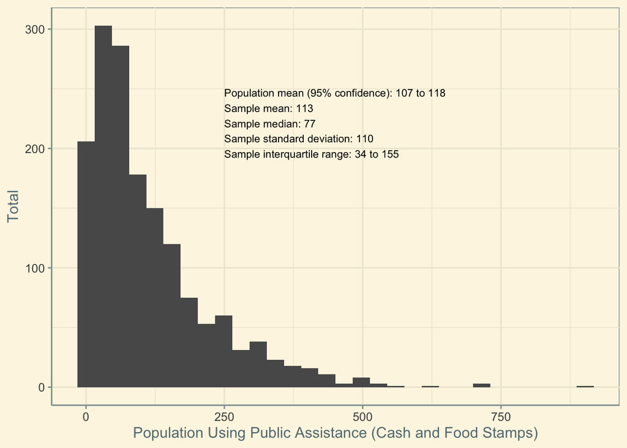

```r
hist15+
  theme_solarized() +
  scale_x_continuous(name = "Population Using Public Assistance (Cash and Food Stamps)") +
  scale_y_continuous(name = "Total") +
  annotate("text", x = 250, y = 250, size = 3,
           label = paste("Population mean (95% confidence):",
                         prettyNum(pop_mean15$conf.int[1], digits = 0),
                         "to",
                         prettyNum(pop_mean15$conf.int[2], digits = 0),

                         "\nSample mean:",
                         prettyNum(mean(cash_assistE), digits = 0),
                         "\nSample median:",
                         prettyNum(median(cash_assistE), digits = 0),
                         "\nSample standard deviation:",
                         prettyNum(sd(cash_assistE), digits = 0),
                         "\nSample interquartile range:",
                         prettyNum(quantile(cash_assistE)["25%"], digits = 0),
                         "to",
                         prettyNum(quantile(cash_assistE)["75%"], digits = 0)),
           hjust = 0, vjust = 1)
```

### Population Not Receiving Public Assistance Summary Stats and Distribution

```r
summary(no_assistE)
```

```
##    Min. 1st Qu.  Median    Mean 3rd Qu.    Max.
##       0    1196    1601    1668    2078    7833
```

```r
sd(no_assistE)
```

```
## [1] 679.2277
```

```r
pop_mean16 <- t.test(no_assistE)
pop_mean16
```

```
##
##  One Sample t-test
##
## data:  no_assistE
## t = 97.863, df = 1587, p-value < 2.2e-16
## alternative hypothesis: true mean is not equal to 0
## 95 percent confidence interval:
##  1634.610 1701.475
## sample estimates:
## mean of x
##  1668.042
```

```r
hist16 <- ggplot(Bay_tract_data, aes(x = no_assistE)) +
  geom_histogram()
```

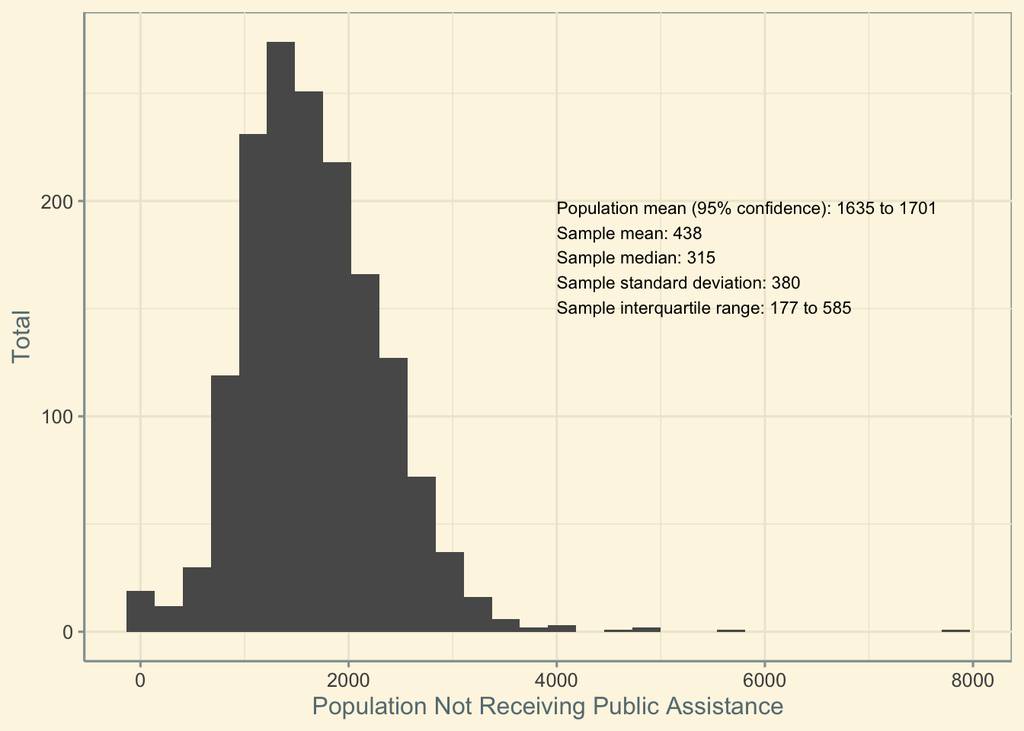

```r
hist16+
  theme_solarized() +
  scale_x_continuous(name = "Population Not Receiving Public Assistance") +
  scale_y_continuous(name = "Total") +
  annotate("text", x = 4000, y = 200, size = 3,
           label = paste("Population mean (95% confidence):",
                         prettyNum(pop_mean16$conf.int[1], digits = 0),
                         "to",
                         prettyNum(pop_mean16$conf.int[2], digits = 0),

                         "\nSample mean:",
                         prettyNum(mean(poverty_100E), digits = 0),
                         "\nSample median:",
                         prettyNum(median(poverty_100E), digits = 0),
                         "\nSample standard deviation:",
                         prettyNum(sd(poverty_100E), digits = 0),
                         "\nSample interquartile range:",
                         prettyNum(quantile(poverty_100E)["25%"], digits = 0),
                         "to",
                         prettyNum(quantile(poverty_100E)["75%"], digits = 0)),
           hjust = 0, vjust = 1)
```

### Categorical Variable Calculation: Bay

My categorical variables for this dataset are county, region, and whether or not the tract meets/exceeds or is below the statewide average HS graduation rate of 83%. I’ve only performed caluclations on HS graduation rate here because the county and region variables are set and cannot be estimated or calculated.

```r
meets_hs_grads2 <- t.test(majority_hs_grads)
below_hs_grads2 <- t.test(!majority_hs_grads)
```

```r
grads_shares2 <- tibble(Diplomas = c("Meets Statewise Average",
                                    "Below Statewide Average"),
                     `Sample` =c(paste(prettyNum(meets_hs_grads2$estimate*100,
                                         digits = 3), "%"),
                         paste(prettyNum(below_hs_grads2$estimate*100,
                                         digits = 3), "%")),
                      `95-percent confidence interval` =
                        c(paste(prettyNum(meets_hs_grads2$conf.int[1]*100,
                                          digits = 3), "% to ",
                                prettyNum(meets_hs_grads2$conf.int[2]*100,
                                          digits = 3), "%"),
                         paste(prettyNum(below_hs_grads2$conf.int[1]*100,
                                          digits = 3), "% to ",
                                prettyNum(below_hs_grads2$conf.int[2]*100,
                                          digits = 3), "%")))
knitr::kable(grads_shares2, caption = "Census Tracts in Bay Region")
```

Census Tracts in Bay Region

| Diplomas | Sample | 95-percent confidence interval |
| --- | --- | --- |
| Meets Statewise Average | 75.5 % | 73.3 % to 77.6 % |
| Below Statewide Average | 24.5 % | 22.4 % to 26.7 % |